# ベイズ統計02-二項分布とベータ分布-

UPDATE: 2024-01-07 16:08:52.744396

# はじめに

このノートは「ベイズ統計」に関する何らかの内容をまとめ、ベイズ統計への理解を深めていくために作成している。今回は「社会科学のためのベイズ統計モデリング」の第8章を写経していく。基本的には気になった部分を写経しながら、ところどころ自分用の補足をメモすることで、自分用の補足資料になることを目指す。私の解釈がおかしく、メモが誤っている場合があるので注意。

- [社会科学のためのベイズ統計モデリング](https://www.asakura.co.jp/detail.php?book_code=12842)

## 8.2.1 藤井七段の対戦成績

今回使用するデータは将棋棋士の藤井七段の100試合の勝敗データ。この100試合のデータから藤井七段の強さを推定することが今回の分析目的。単純集計だと85勝15敗で勝率85%となる。

```r
library(dplyr)
library(rstan)
library(ggplot2)

options(max.print = 999999)
rstan_options(auto_write=TRUE)
options(mc.cores=parallel::detectCores())

d <- read.table('https://raw.githubusercontent.com/HiroshiHamada/BMS/master/ch08/Fujii.txt')

table(d)
```

```
## V1
##  0  1
## 15 85
```

```r
# ggplot(data = data,aes(x = game,y = win+lose,fill = win)) +
#   geom_point(size = 2.5, shape = 21, stroke = 0.5) +
#   scale_fill_gradient(low  =  "black",high  =  "white") +
#   scale_x_continuous(breaks  =  c(1,seq(10,100,5))) +
#   ylim(0.9,1.1) +
#   theme( panel.background  =  element_blank(),
#          panel.grid  =  element_blank(),
#          axis.title.x  =  element_blank(),
#          axis.text = element_blank(),
#          axis.title.y  =  element_blank(),
#          axis.text.y  =  element_blank(),
#          axis.ticks.y  =  element_blank(),
#          legend.position  =  "none")
```

## 8.2.2 ベルヌーイ・モデル

ここでは、勝ちを1、負けを0とする確率変数$Y_{i}$とする。$Y_{i}$は独立であり、$q$をパラメタとするベルヌーイ分布に従うと仮定する。事前分布は$Beta(\alpha=1,\beta=1)$のベータ分布に従うと仮定する。

モデル1

$$\begin{eqnarray}
Y_{i} &\sim& Bernoulli(q), \ \ i = 1...n\\
q &\sim& Beta(\alpha, \beta)
\end{eqnarray}$$

ここで使用するベルヌーイ・モデルについては、第3章でわかりやすく解説されている。内容をメモしたものを貼り付けておく。

Bernoulli-Beta Model

$n+1$試合目の予測分布は下記のパラメタを持つベルヌーイ分布に従う。

$$E[q] = \frac{\alpha+\sum y_{i}}{\alpha+\beta+n}$$

## 8.2.3 藤井七段のデータ分析

勝利確率$q$の事後分布と予測分布を1試合終るごとにデータから推定する。データを得る前の状態は不明なので、$q$の事前分布は$Beta(\alpha=1,\beta=1)$のベータ分布に従うと仮定する。

```r
data <- tibble(
  game = 1:100,
  win = d$V1,
  lose = 1-win
) %>%
  mutate(
    cumwin = cumsum(win),
    cumlose = cumsum(lose),
    mle = cumwin/game
  )

print(data, n = 100)
```

```
## # A tibble: 100 × 6
##      game   win  lose cumwin cumlose   mle
##     <int> <int> <dbl>  <int>   <dbl> <dbl>
##   1     1     1     0      1       0 1
##   2     2     1     0      2       0 1
##   3     3     1     0      3       0 1
##   4     4     1     0      4       0 1
##   5     5     1     0      5       0 1
##   6     6     1     0      6       0 1
##   7     7     1     0      7       0 1
##   8     8     1     0      8       0 1
##   9     9     1     0      9       0 1
##  10    10     1     0     10       0 1
##  11    11     1     0     11       0 1
##  12    12     1     0     12       0 1
```

[output cut: 88 more lines]

可視化するためのデータを用意する。事後分布の平均、95%ベイズ信頼区間を計算している。

```r
## posterior
postdata <- tibble(
  game = 0:100,
  win = c(NA, data$win),
  lose = c(NA, data$lose),
  cumwin = c(NA,data$cumwin),
  cumlose = c(NA,data$cumlose),
  post_alpha = c(1,data$cumwin+1),
  post_beta = c(1,data$cumlose+1),
  mle = c(NA,data$mle),
  post_mu = post_alpha / (post_alpha+post_beta),
  post_med = qbeta(0.500, post_alpha, post_beta),
  CI_lower = qbeta(0.025, post_alpha, post_beta),
  CI_upper = qbeta(0.975, post_alpha, post_beta)
)

print(postdata, n = 100)
```

```
## # A tibble: 101 × 12
##      game   win  lose cumwin cumlose post_alpha post_beta    mle post_mu
##     <int> <int> <dbl>  <int>   <dbl>      <dbl>     <dbl>  <dbl>   <dbl>
##   1     0    NA    NA     NA      NA          1         1 NA       0.5
##   2     1     1     0      1       0          2         1  1       0.667
##   3     2     1     0      2       0          3         1  1       0.75
##   4     3     1     0      3       0          4         1  1       0.8
##   5     4     1     0      4       0          5         1  1       0.833
##   6     5     1     0      5       0          6         1  1       0.857
##   7     6     1     0      6       0          7         1  1       0.875
##   8     7     1     0      7       0          8         1  1       0.889
##   9     8     1     0      8       0          9         1  1       0.9
##  10     9     1     0      9       0         10         1  1       0.909
##  11    10     1     0     10       0         11         1  1       0.917
##  12    11     1     0     11       0         12         1  1       0.923
```

[output cut: 90 more lines]

連勝している間は1と推定する最尤推定と比べ、事後分布は不確実性を考慮して、最初の方は信用区間も広く、事後平均も低い。多くのデータが観察できた後半の試合では、平均も安定し、信用区間も狭くなっている。

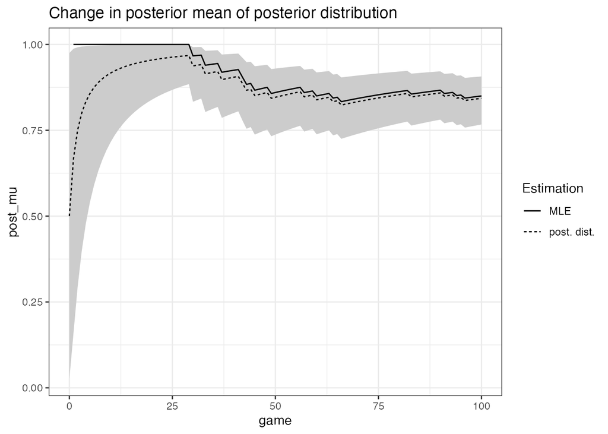

```r
ggplot(data = postdata) +
  geom_ribbon(aes(x = game,y = post_mu,
                  ymin = CI_lower, ymax = CI_upper), fill = 'grey80')+
  geom_line(aes(x = game,y = mle,linetype  =  'MLE')) +
  geom_line(aes(x = game,y = post_mu, linetype= 'post. dist.')) +
  labs(linetype = 'Estimation') +
  ggtitle('Change in posterior mean of posterior distribution') +
  theme_bw()
```

事後分布の確率密度関数の変化をプロットする。最初は先程と同じく不確実性を考慮しているものの、最後の方は安定した分布になっている。

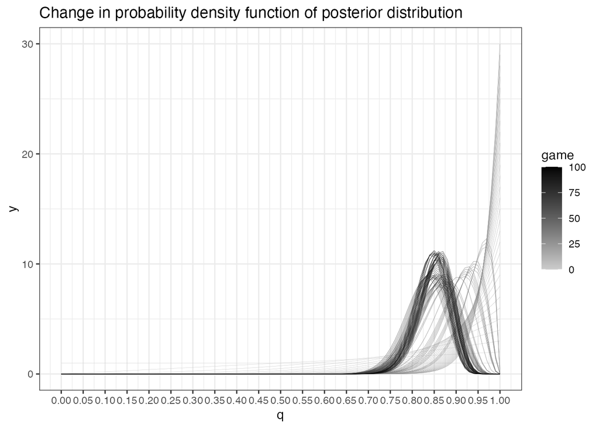

```r
# x <- seq(0,1,0.001)
# plot(x, dbeta(x, shape1 = 86, shape2 = 16), type = 'l')
ggplot(data = tibble(q = c(0,1)), aes(x = q)) +
  purrr::pmap(list(a = postdata$post_alpha, b = postdata$post_beta, co = postdata$game),
       function(a, b, co)
         stat_function(fun = dbeta, args = list(shape1 = a, shape2 = b), aes_q(color = co), size = 0.1)
  ) + labs(color = 'game') +
  scale_colour_gradient(low = 'grey80', high = 'black') +
  scale_x_continuous(breaks = seq(0, 1, 0.05)) +
  ggtitle('Change in probability density function of posterior distribution') +
  theme_bw()
```

## 8.2.5 先手後手で強さが変わるのか

一般的には将棋は先手が有利で、後手が不利とも言われる。先手後手の要因を入れてモデルを拡張する。$i$試合目の先手後手を区別する変数$x_{i}$を導入し、先手は$x=1$とする。

モデル1

$$\begin{eqnarray}
Y_{i} &\sim& Bernoulli(x_{i}q_{1} + (1-x_{i})q_{0}), \ \ i =
1...n\\
q_{0} &\sim& Beta(\alpha_{0}, \beta_{0}) \\
q_{1} &\sim& Beta(\alpha_{1}, \beta_{1}) \\
\end{eqnarray}$$

Stanのモデルは下記の通り。

```
data {
  int N;
  int X[N];
  int Z[N];

}

parameters {
  real<lower=0,upper=1> q1;
  real<lower=0,upper=1> q0;
}

model {
  for (n in 1:N) {
    X[n] ~ bernoulli(Z[n]*q1+(1-Z[n])*q0);
  }
}
```

このモデルを少し深掘りしておく。下記の通り、`z`が切り替わることで、`x[n]`が従う分布が異なるパラメタから生成される考えている。

```
model {
  for (n in 1:N) {
    X[n] ~ bernoulli(Z[n]*q1+(1-Z[n])*q0);
  }
}
// z = 1のとき
// X[n] ~ bernoulli(1*q1); -> X[n] ~ bernoulli(q1);
// z = 0のとき
// X[n] ~ bernoulli(Z(1-0)*q0); -> X[n] ~ bernoulli(q0);
```

データを用意して、

```r
d <- read.table('https://raw.githubusercontent.com/HiroshiHamada/BMS/master/ch08/Fujii_first.txt', header = TRUE)
data <- list(N = nrow(d), X = d$win, Z = d$first)
data
```

```
## $N
## [1] 100
##
## $X
##   [1] 1 1 1 1 1 1 1 1 1 1 1 1 1 1 1 1 1 1 1 1 1 1 1 1 1 1 1 1 1 0 1 1 0 1 1 1 0
##  [38] 1 1 1 1 0 0 1 0 1 1 1 0 1 1 1 1 1 1 1 0 1 1 0 1 1 1 0 1 0 1 1 1 1 1 1 1 1
##  [75] 1 1 1 1 1 1 1 1 0 1 1 1 1 1 1 1 0 1 1 0 1 0 1 1 1 1
##
## $Z
##   [1] 0 1 0 1 1 1 0 0 1 1 0 1 0 0 0 0 0 0 0 1 1 1 1 0 0 0 0 1 1 0 1 0 0 1 0 1 0
##  [38] 0 0 0 0 0 0 0 0 1 1 1 1 0 1 0 1 0 0 0 0 0 1 1 1 0 0 1 1 1 0 0 1 1 1 0 0 0
##  [75] 1 1 1 0 1 1 1 1 0 1 0 1 0 0 1 0 0 0 0 0 1 0 0 0 0 1
```

ここでは、`stan_model()`関数で最初にコンパイルしておいてから、

```r
model <- stan_model('note_bayes02−001.stan')
```

`sampling()`関数でサンプリングする。

```r
fit <- sampling(object = model, data = data, seed = 1989)
```

```r
print(fit)
```

```
## Inference for Stan model: anon_model.
## 4 chains, each with iter=2000; warmup=1000; thin=1;
## post-warmup draws per chain=1000, total post-warmup draws=4000.
##
##        mean se_mean   sd   2.5%    25%    50%    75%  97.5% n_eff Rhat
## q1     0.89    0.00 0.05   0.79   0.86   0.89   0.92   0.96  2584    1
## q0     0.80    0.00 0.05   0.69   0.77   0.80   0.84   0.89  3047    1
## lp__ -46.55    0.03 1.06 -49.32 -46.99 -46.21 -45.79 -45.52  1696    1
##
## Samples were drawn using NUTS(diag_e) at Sun Jan  7 16:09:18 2024.
## For each parameter, n_eff is a crude measure of effective sample size,
## and Rhat is the potential scale reduction factor on split chains (at
## convergence, Rhat=1).
```

事後分布を可視化しておく。

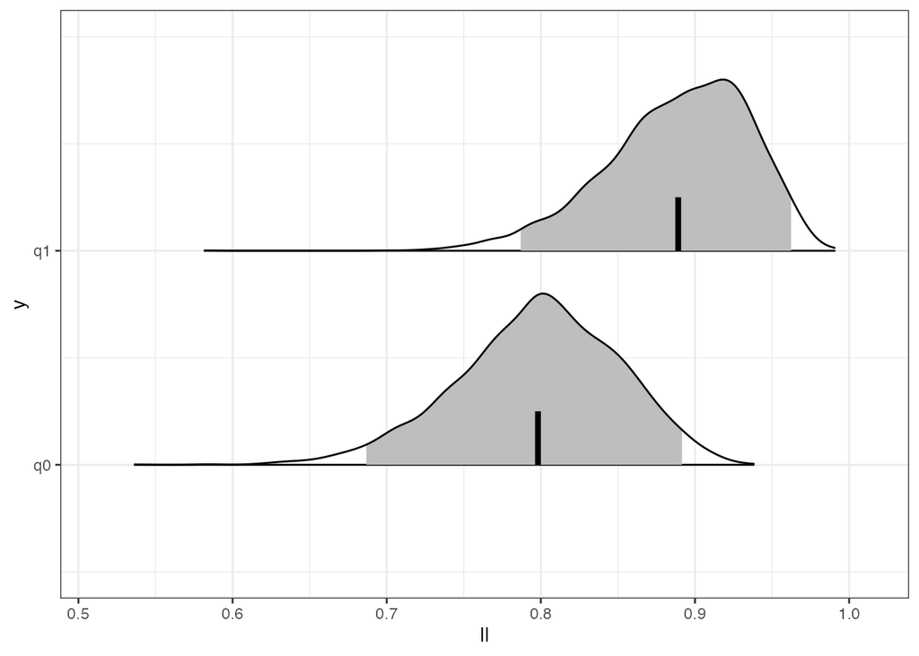

```r
stan_plot(
  fit,
  point_est = "mean",
  ci_level = 0.95,
  outer_level = 1.00,
  show_density = TRUE,
  fill_color = "grey") +
  theme_bw()
```

## 参考文献および参考資料

- [社会科学のためのベイズ統計モデリング](https://www.asakura.co.jp/detail.php?book_code=12842)